# Beginning MLOps with MLFlow (Building Models)

## Chapter Two: Building Models

In this notebook, we will go over how to build a simple logistic regression model in both **scikit-learn** and **PySpark**. We will also go over the process of **k-fold cross validation** to tune hyperparameters in **scikit-learn**.

### Introduction

In the previous notebook, you loaded the credit card data set and analyzed the distribution of its data. You also looked at the relationships between the features and got a general idea of how heavily they influence the labels.

Now that you've gained a better undestanding of the data set, you will proceed with building the models themselves. You will be using the same credit card data set as in the previous notebook. In this notebook, you will look at two frameworks **scikit-lean** and **PySpark**. The models you build in scikit-learn and PySpark will stasy relevant for the rest of the notebooks, as you will be using both of them later on when you host them on **cloud services** to make predictions. You will keep it simple and construct logistic regression models in these two frameworks. Since the input data format is different for these two frameowrks, you can't just conduct the data processing in advance and use those train/test/validate sets for these two frameworks. However, it is possible to do so for scikit-learn and **Keras**, for example, depending on how the last layer is constructed in the **Keras** model.

You will be performing the validation step with the scikit-learn model to tune a hyperparameters. **Hyperparameters** can be thought of as a model related parameters that influence the training process and result.

That being said, let's get started with scikit-learn and build a logistic regression model. One thing to note is that we will provide a lot of commentary in the scikit-learn model that we may skip over in the PySparkexample, so be sure to at least read through the process for scikit-learn to get a general idea of how train-test-validate works.

### Scikit-Learn

Before we get started, here are the packages and their versions that you will need. We will provide an easy way for you to check the versions of your packages within the code itself.

In the code below, you will find that some of the imports are unnecessary, such as importing all of sklearn when you only use a bit of its functionality. This is done for the purpose of displaying the version and such statemets have a # beside them.

### Scikit-Learn: Data Processing

So now, let's begin with the import statements:

```python
import numpy as np
import pandas as pd
import matplotlib #
import matplotlib.pyplot as plt
import seaborn as sns
import sklearn #
from sklearn.linear_model import LogisticRegression
from sklearn.model_selection import train_test_split
from sklearn.preprocessing import StandardScaler
from sklearn.metrics import roc_auc_score, plot_roc_curve, confusion_matrix
from sklearn.model_selection import KFold

print('numpy: {}'.format(np.__version__))
print('pandas: {}'.format(pd.__version__))
print('matplotlib: {}'.format(matplotlib.__version__))
print('seaborn: {}'.format(sns.__version__))
print('sklearn: {}'.format(sklearn.__version__))
```

```
numpy: 1.19.5
pandas: 0.24.2
matplotlib: 2.2.2
seaborn: 0.10.0
sklearn: 0.23.2
```

The output shows the printed versions of the modules you will need. Some of the modules are imported for the sake of printing the versions and have been marked with a # baside them to indicate that they are not necessary to run the code.

Now you can move on to loading the data. You willbe using the same credit card dataset as from the previous notebook:

```python
data_path = 'creditcard.csv'

df = pd.read_csv(data_path)
```

Loading the data frame using pandas. The credit card data set is located in the same directory as the notebook file.

There shouldn't be any output from loading the data frame. To see the data frame you just loaded, call the following to ensure it has read the data correctly:

```python
df.head()
```

|  | Time | V1 | V2 | V3 | V4 | V5 | V6 | V7 | V8 | V9 | ... | V21 | V22 | V23 | V24 | V25 | V26 | V27 | V28 | Amount | Class |
| --- | --- | --- | --- | --- | --- | --- | --- | --- | --- | --- | --- | --- | --- | --- | --- | --- | --- | --- | --- | --- | --- |
| 0 | 0.0 | -1.359807 | -0.072781 | 2.536347 | 1.378155 | -0.338321 | 0.462388 | 0.239599 | 0.098698 | 0.363787 | ... | -0.018307 | 0.277838 | -0.110474 | 0.066928 | 0.128539 | -0.189115 | 0.133558 | -0.021053 | 149.62 | 0 |
| 1 | 0.0 | 1.191857 | 0.266151 | 0.166480 | 0.448154 | 0.060018 | -0.082361 | -0.078803 | 0.085102 | -0.255425 | ... | -0.225775 | -0.638672 | 0.101288 | -0.339846 | 0.167170 | 0.125895 | -0.008983 | 0.014724 | 2.69 | 0 |
| 2 | 1.0 | -1.358354 | -1.340163 | 1.773209 | 0.379780 | -0.503198 | 1.800499 | 0.791461 | 0.247676 | -1.514654 | ... | 0.247998 | 0.771679 | 0.909412 | -0.689281 | -0.327642 | -0.139097 | -0.055353 | -0.059752 | 378.66 | 0 |
| 3 | 1.0 | -0.966272 | -0.185226 | 1.792993 | -0.863291 | -0.010309 | 1.247203 | 0.237609 | 0.377436 | -1.387024 | ... | -0.108300 | 0.005274 | -0.190321 | -1.175575 | 0.647376 | -0.221929 | 0.062723 | 0.061458 | 123.50 | 0 |
| 4 | 2.0 | -1.158233 | 0.877737 | 1.548718 | 0.403034 | -0.407193 | 0.095921 | 0.592941 | -0.270533 | 0.817739 | ... | -0.009431 | 0.798278 | -0.137458 | 0.141267 | -0.206010 | 0.502292 | 0.219422 | 0.215153 | 69.99 | 0 |

5 rows × 31 columns

You should see the output of the *head()* function. The data has loaded correctly, and you can see the first five rows of the data frame.

If you remember from the previous notebook, there is massive imbalance in the distribution of data between the normal data and the anomalies. Because of this, you are going to take a slightly alternative apporach in how you craft this data.

This is where the data analysis comes into play. Because you know that a massive disparity between the data counts in each class exists, you will now take careto specially craft the data sets so that it is ensures that a good amount of anomalies end up in each data set. If you simply slect 100,000 points from df, split it into your training/test/validate sets and continue, it is entirely possible that very few or even no anomalies end up in one or more of those sets. At this point, you would have a lot of trouble in getting the model to properly learn this task.

This is why you will be splitting up the anomalies and normal points to create your training/test/validate sets.

With that in mind, let's create data frames for the normal points and for the fraudulent points.

```python
normal = df[df.Class == 0].sample(frac = 0.5, random_state = 2020).reset_index(drop = True)
anomaly = df[df.Class == 1]
```

You have set the *random_state* to a specific value so that the results of the random sampling should be the same no matter how many times you repeat it, helping with reproducibility. Unfortunately, given the nature of how models learn, you cannot expect to get the same results every time for something like neural networks, for example.

In the code, you filter out the respective values by class, and sample 50% of the entire data frame's normal points to comprise the normal data in this context.

In the above cell we filtered the data frame values by class to create the normal and anomaly data frames. The normal data frame contains 50% of all normal data points, randomly selected as determined by the seed (*random_state*)

You can add some code to check trhe shapes as well:

```python
print(f'Normal: {normal.shape}')
print(f'Anomaly: {anomaly.shape}')
```

```
Normal: (142158, 31)
Anomaly: (492, 31)
```

The above cell prints the shapes of the normal and the anomaly data frames. There is a clear difference in the number of entries in the two data frames.

As you can see, there is still a big displarity between the normal points and the anomalies. In the case of logistic regression, the model is still able to learn how to distinguish between the two, but in the case of neural networks, for example, this disparity means that the model never really learns ho to classify anomalies. However, as you will see later in this notebook, you can tell the model to weigh the anomalies far more in its learning process compared to the normal points.

Now you can start creating the train/test/validate split. However, scikit-learn provides functionality to create train/test splits only. To get around that, you will create train and test sets, and then split the train set again into train an validate sets.

First, you will split the data into train and test data, keeping the normal points and anomalies separate. To do this, you will use the *train_test_split()* function from scikit-learn. Commonly passed parameters are

- x: the x set you want to split up.
- y: the y set you want to split up corresponding to the x set
- test_size: The proportion of data in x and y you want to randomly sample for the test set.

And so, to split up x and y into your training and testing sets, you may see colde like the following:

*x_train, x_test, y_train, y_test = train_test_split(x, y, test_size = 0.2, random_state = 2020)*

Just like earlier, *random_state* is setting the random seed so that every time you run it, the data will be split in the same way.

If you don't pass the y parameters, you simply get a split on the x data. And so, keeoing that in mind, let's split up your normal points and anomalies into training and testing sets:

```python
normal_train, normal_test = train_test_split(normal, test_size = 0.2, random_state = 2020)
anomaly_train, anomaly_test = train_test_split(anomaly, test_size = 0.2, random_state = 2020)
```

There should be no output from the above cell where we split the normal and anomaly data frames into train and set subsets. The respective test sets compreise of 20% of the original sets.

Now, you can create your training and validation sets by calling the same function on the respective training sets. You don't want to split it by 20% again, though, since the training set is already 80% of the original data set. If you used a 20% split again, the validation set would be 16% of the original data, and the training set would be 64% of the original data. You will instead be doing a 60-20-20 split for training, testing, and validation data, respectively, and so you will be using a new *test_size* values of 25% to ensure these proportions hold (0.25 * 0.8 = 0.2).

With that in mind, let's create your training and validation splits:

```python
normal_train, normal_validate = train_test_split(normal_train, test_size = 0.25, random_state = 2020)
anomaly_train, anomaly_validate = train_test_split(anomaly_train, test_size = 0.25, random_state = 2020)
```

You have created train and validate splits from the training data. You have chosen to make the validation set comprise 25% of the respective original training set. As these original training sets themselves comprise 80% of the original normal and anomaly data frames, the respective validation splits are 20% (0.25 *0.80) of their original normal and anomaly data frames. Ans so, the final training split also becomes 60% of the original, as 0.75* 0.80 = 0.6.

To create you final training, testing, and validation sets, you have to concatenate the respective normal, and anomaly data splits.

First, you define *x_train*, *x_test*, and *x_validate*:

```python
x_train = pd.concat((normal_train, anomaly_train))
x_test = pd.concat((normal_test, anomaly_test))
x_validate = pd.concat((normal_validate, anomaly_validate))
```

Next, you define *y_train*, *y_test*, and *y_validate*:

```python
y_train = np.array(x_train['Class'])
y_test = np.array(x_test['Class'])
y_validate = np.array(x_validate['Class'])
```

Finally, you have to drop the column *Class* in the x_sets since it would defeat the purpose of teaching the model how to learn what makes up a normal and a fraudulent transaction if you gave it the label directly:

```python
x_train = x_train.drop('Class', axis = 1)
x_test = x_test.drop('Class', axis = 1)
x_validate = x_validate.drop('Class', axis = 1)
```

You created the respective *x* and *y* splits of the training, testing, and validation sets. The *x* sets are the combinations of the normal and anomaly sets for each split (train, test, validate), while the *y* sets are simply the data in the *Class* of those *x* sets. You then dropped the label column from the *x* sets.

Let's get the shapes of the sets you just created:

```python
print('Training sets:\nx_train: {} y_train: {}'.format(x_train.shape, y_train.shape))
print('Testing sets:\nx_test: {} y_test: {}'.format(x_test.shape, y_test.shape))
print('Validation sets:\nx_validate: {} y_validate: {}'.format(x_validate.shape, y_validate.shape))
```

```
Training sets:
x_train: (85588, 30) y_train: (85588,)
Testing sets:
x_test: (28531, 30) y_test: (28531,)
Validation sets:
x_validate: (28531, 30) y_validate: (28531,)
```

You just printed the output of the different sets. The three sets should comprise 60%, 20%, and 20% of the original union of the normal and anomaly sets.

Looking at the data analysis, you can see that some of the valuesget really large. The fine details are beyondthe scope of this notebook, but when some features have a relatively small range but other have an extremely large range (think of the range of *V1* and *Time* from the previous notebook), the model will have a much harder time learning.

In more detail, the model will have a hard time optimizing the cost function and may take many more steps to converge, if it is able to do so at all.

And so it is better to scale everything down by normalizing the data. You will be using scikit-learn *StandardScaler*, which normalizes all of the data such that the mean is 0 and the standard deviation is 1.

Here is the code to standardize your data:

```python
scaler = StandardScaler()
scaler.fit(pd.concat((normal, anomaly)).drop('Class', axis = 1))

x_train = scaler.transform(x_train)
x_test = scaler.transform(x_test)
x_validate = scaler.transform(x_validate)
```

It is important to note that you are fitting the scaler on the entire data frame so that it standardizes all of you data in the same way. This is to ensure the best results since you don't want to standardize *x_train*, *x_test*, and *x_validate* in their own ways since it would create discrepancies in the data and would be problematic for the model. Of course, once you've deployed the model and start receiving new data, you will standardize it using the scaler from the training process, but this new data could possibly come from a slightly different distribution than you training data. This would especially be the case if trends start shifting - this new standardized data could possibly lead to a tougher time for the model since it wouldn't fit very well in the distribution that the model trained on.

On the above cell, you fitted a standard scaler object on a concatenation of the normal and anomaly data frames. This is done so that each of the train, test, and validate subsets will be scales according to the same standard, ensuring that there are no discrepancies between the scaling of data.

### Scikit-Learn: Model Training

Finally, you can just define your logisctic regression modeL:

```python
sk_model = LogisticRegression(random_state = None, max_iter = 400, solver = 'newton-cg').fit(x_train, y_train)
```

In the above cell you defined the logistic regression model and trained on the training data set. There should not be any outputs after execution if it all goes well. Any errors you might see could involve a failure to converge. For that, changing the *max_iter* parameter could help, and changing the *solver* algorithm could help as well.

After the training process, either the evaluation step or validation step can come next. As long as the testing set and the validation set come from different distributions (the validation set is derived from the training set, while the testing set is derived from the original data), the model is technically seeing new data in the evaluation and in the validation processes.

The context also matters. If you are using the validation process to select the best model out of a set of trained models, then the validation process can come after the training process. You can still evaluate one or all of your trained models, but it could be unnecessary because in this context you're trying to find the best model for the code.

In the context where you're trying to tune your hyperparameters for a model you are going to stick with, it doesn't matter whether you do the evluation first or the validation first. Doing the evaluation first, as you will be doing shortly, can give you a good idea of how wellthe model is doing currently before starting the validation step. The model will never learn from the evaluation data, so there's no harm in evaluating the model on this data.

In this example, you are looking at tuning the hyperparameter for class weights (how much to weight a normal sample and how much to weight a fraudulent sample).

Bur first, let's evaluate you model to get a deeper understanding of how everything works.

### Scikit-Learn: Model Evaluation

You can now look at accuracy an **AUC scores**. First, you find the accuracy using the built-in score function of the model:

```python
eval_acc = sk_model.score(x_test, y_test)
```

Next, let's get the list of predictions from the model to help calculate the **AUC score**. **AUC** is usually a better metric since it better explains the performance of the model. The general gist of it is that a model that perfectly classifies every point correctly will have an **AUC score** of 100%.

The problem with accuracy in this context is that if there are 100,000 normal points and perhaps around 100 anomalies, the model can classify all of the normal points correctly and none of the anomalies and still get a really high accuracy above 99%. However, the **AUC score** would show a value much lower at around 0.5. An **AUC** of 0.5 mean that the model know nothing and is practically just guessing randomly, but in this case, it means that the model only ever predicts "normal" for any point it sees. In other words, it hasn't actually learned much of anything if it doesn't know how to predict an anomaly.

It's also worth mentioning that **AUC** isn't the sole metric by which one should base the worthiness of a model, since context matters. In this case, normal points far outnumber anomalies, so accuracy is relatively poor metric to solely judge model performance on. **AUC scores** in this case would reflect the mode's performance well, but it's also possible to get higher **AUC scores** but lower accuracy scores. That just means you must look at the results carefully to understand exactly what's happening. To help with this, you will look at **"confusion matrix"** shortly.

Now, let's get the predictions and calculate the **AUC score**:

```python
preds = sk_model.predict(x_test)
auc_score = roc_auc_score(y_test, preds)
```

Finally, let's print out the scores:

```python
print(f'AUC Score: {auc_score:.3%}')
print(f'Eval Accuracy: {eval_acc:.3%}')
```

```
AUC Score: 84.331%
Eval Accuracy: 99.867%
```

You just printed out the **AUC score** and the accuracy for the scikit-learn logistic regression model.

In this case, both the **AUC score** and the accuracy score are high. Between the two, the accuracy score is definitely inflated by the number of of normal points that exist, but the **AUC score** indicate that the model does a pretty good job at distinguishing between the anomalies and the normal points.

Scikit-learn actually provides a function that lets you see the **ROC curve** - the figure from which the **AUC score** (or "area under the curve") is derived from. Run the following:

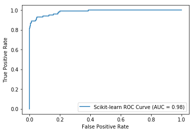

```python
roc_plot = plot_roc_curve(sk_model, x_test, y_test, name = 'Scikit-learn ROC Curve')
```

The cell above shows the **ROC curve** generated for the logistic regression model you just trained. A **ROC curve** starting with a true positive value of 1.0 at a false positive value of 0.0 is the best possible curve in theory. From that point, it should keep going right while maintaining its value as it hits 1.0 on the x-axis. This graph is quite close to that ideal, hence why the **AUC score** is so high at 0.98. The discrepancy in **AUC score** here compared to when you calculated it earlier has to do with how the value is actually calculated.

What's basically happening in that scikit-learn takes in the model and the evaluation set to dynamicaly generate the curve as it predicts on the test sets. The metrics you see on the axes are derived from how correctly the model predicts each of the values. The "true positive rate" and the "false poitive rate" are derived from the values on the **confusion matrix** that you will see below.

From that graph, the **AUC score** is generated. You can see that it differes from the score that was calculated earlier, but this can be attributed to the two functions calculating the scores slightly differently.

Let's now build the confusion matrix and plot it using seaborn:

```
Text(0.5,15,'Predicted')
```

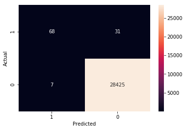

```python
conf_matrix = confusion_matrix(y_test, preds)
ax = sns.heatmap(conf_matrix, annot = True, fmt = 'g')
ax.invert_xaxis()
ax.invert_yaxis()
plt.ylabel('Actual')
plt.xlabel('Predicted')
```

The above cell shows the confusion matrix plot of the results of training. The accuracy for the normal points is very good, but the accuracy for the anomaly points is ok. There is still further room for improvement looking at these results, as you have not tuned the hyperparameters of the model yet, but it already does ok on detecting anomalies. The goal now is to keep the accuracy for the normal ponts as high as possible, or at a high enough level that's acceptable. Based on this **confusion matrix** plot, you can now seet that the lower **AUC score** of 0.84 is a much better indicator of the model's performance that the graph's apparent score of 0.98.

This is what a confusion matrix looks like. TRhe y-axis consists of the true labels, while the x-axis cosnsits of the predicted labels. When the true label is "0" and the model predicts "0", we call this a **true negative**. "True" refers to the true label, and "negative" refers to the label the model predicts.

What counts as "positive" and what counts as "negative" can differ. In taks such as disease detection, if a test finds someone to have the disease they are said to be "true positive". Otherwise, they "test negative". Anomaly detection is similar. When a model thinks that a point is an anomaly, it flags it with a label "1". An so, a point is labeled "positive" if the model thinks is an anomaly, and "negative" if it doesn't.

You may notice that we have inverted the axes in the code. This is simply to get in the format so that the top left of the matrix corresponds to "true positives", the top right of the matrix corresponds to "false negatives", the bottom left of the matrix corresponds to "false positves", and the bottom right of the matrix corresponds to "true negatives".

To quickly recap these concepts:

- **True positives** are values that the model predicts as positive that actually are positive.
- **False negatives** are values that the model predicts as negative that acutally are positive.
- **False positives** are values that the model predicts as positive that acutally are negative.
- **True negatives** are values that the model predicts as negative that actually are negative.

To look at how well the model identifies anomalies, look at the "1" row on the y-axis. The sum of this trow shouls equal the total number of anomalies in the test set: 99 anomalies. TRhe model predicted about 68.7% of the anomalies correctly (68/(68 + 31)) and predicted 99.98% of the normal points correctly (28425/(28425 + 7)) looking at the bottom row.

As you can see, the confusion matrix gives us a really good look at the true performance of the model. You now know that it does very well in the task of predicting normal points but does an ok job at prediting anomalies. That being said, the model can still predict a majority of anomalies correctly. And so you can see that the **AUC score** of 0.84 was much more accurate at indicating the performance of the model than the graph, which had an **AUC** of 98%. With an **AUC** of 0.98, you can expect that there are very, very few instances of false negatives or false positives.

### Scikit-Learn: Model Validation

Let's now look at how to use the process of **k-fold corss-validation** to compare several hyperparameter values. After the validation process has ended, you will compare the evaluation metrics to get a better idea of what hyperparameter setting works the best.

The hyperparameter you want to tune is how much you want to weight the anomalies by compared to the normal data points. By default, both of them are weighted equally. Let's define a list of weights to iterate over.

```python
anomaly_weights = [1, 5, 10, 15]
```

Next, you define the number of foldes and initialize your data fold generator.

```python
num_folds = 5
kfold = KFold(n_splits = num_folds, shuffle = True, random_state = 2020)
```

What this *KFold()* function does is that is splits the data passed in into *num_folds* different partitions. A single fold acts as a validation set at a time, while the rest of the foldes are used for training. In this context, the *"validation fold"* is basically what the model will be evaluating on. It is called *"validation"* since it helps us get an idea of how the model is doing on data it has never seen before.

If you have built deep learning models before, you may know that during the training process, you can split a small portion of the training set aside as a validation set. This lets you know during training if you're overfitting or not, as decreasing training loss and increasing validation would indicate.

In the above cell we have set different values for anomaly weights to test with the validation script and constructing the *KFold* data generator. In this case, you are using five folds, so that data passed in will be split five ways.

Now let's define the validation script:

```python
logs = []

for f in range(len(anomaly_weights)):
    fold = 1
    accuracies = []
    auc_scores = []
    for train, test in kfold.split(x_validate, y_validate):
        weight = anomaly_weights[f]
        class_weights = {0:1, 1:weight}
        sk_model = LogisticRegression(random_state = None, max_iter = 400, solver = 'newton-cg', class_weight = class_weights).\
        fit(x_validate[train], y_validate[train])

        for h in range(40):
            print('-', end="")
            print(f'\nfold {fold}\nAnomaly Weight: {weight}')

        eval_acc = sk_model.score(x_validate[test], y_validate[test])
        preds = sk_model.predict(x_validate[test])

        try:
            auc_score = roc_auc_score(y_validate[test], preds)
        except:
            auc_score = -1

        print('AUC: {}\neval_acc: {}'.format(auc_score, eval_acc))

        accuracies.append(eval_acc)
        auc_scores.append(auc_score)

        log = [sk_model, x_validate[test], y_validate[test], preds]
        logs.append(log)

        fold = fold + 1

    print('\nAverages: ')
    print('Accuracy: ', np.mean(accuracies))
    print('AUC: ', np.mean(auc_scores))

    print('Best: ')
    print('Accuracy: ', np.max(accuracies))
    print('AUC: ', np.max(auc_scores))
```

[output not shown]

[output cut: 2413 more lines]

```
-
fold 5
Anomaly Weight: 15
-
fold 5
Anomaly Weight: 15
AUC: 0.8813861631838532
eval_acc: 0.9973711882229233

Averages:
Accuracy:  0.9977568209842593
AUC:  0.9211580090402742
Best:
Accuracy:  0.9985979670522257
AUC:  0.9749591657243373
```

The above cell shows the validation script. The script is quite long, so be sure it is formatted correctly because a single space misalignment can sause issues.

Before you run the script, let's go over what the code does, as that was a lot of code thrown out at once.

The first loop goes over each of the anomaly weights. You set the fold number here equal to 1 and define empty lists to hold values for the accuracy and AUC scores for each run with the current weight parameters.

The second loop goes over the five fold boundaries that the **KFold()** object defines. You set the **class_weights** dictionary and pass it into the model as the hyperparameter. After the training process, you evaluate as usual. There is a **try-except** block for the AUC score in the event that the fold generated only has values of one class (so really if it only has normal data and no anomalies). If the AUC score is -1 for any fold, then you know there was a problem with one of the folds.

You do save the model, the validation data, and the predictions so that you can examine the confusion matrix and plot the ROC curve for anyrun you like. After the end of the five folds, the script then displays averages and the best scores.

The output will be truncated when you run this, so don't forget to expand it like in the previous notebook to look at all of the runs. Feel free to explore the output or even change the number of folds but beware of the results because increasing the number of folds can mean that the number of anomalies must be spread across even more partitions. In this specific context, a lower number of folds is likely to be better because you have so few anomaly points.

When you sift through the output, you can see that the best results occur when the anomaly weight is set to 10. This setting had the highest average AUC score and had the best AUC score as well, resulting the output in the above cell (refer to Anomaly Weight: 10).

By looking at the results of the best setup in the validation script you can see that the best setup turned out to be one where the anomalies were weighted as 10, as it had the best average AUC score and the best AUC score compared with the other anomaly weight parameters. The trye best weight is likely around an anomaly weight of 10, though you must perform another hyperparameter search with a more narrowed range to find the absolute best setting. You can kepp narrowing the search as much as you'd like, but past a certain precision, you will find that you are getting diminishing returns.

Let's examine the plots for this setup since it was the best perfromer of all of them on average.

First, you load the correct log in the list of logs. Since the anomaly weight was 10, and the second fold perfromed the best, you want to look at the twelfth index in the entries in logs. (The first five correspond to indices 0-4, and next five are indices 5-9. With index 10, you begin the first fold with weight ten, so the second fold is at index 11.)

```python
sk_model, x_val, y_val, preds = logs[11]
```

Let's look at the **ROC curve**. Keep in mind that since there is so little data in hte validation set, the AUC score may not be so accurate. Here is the code:

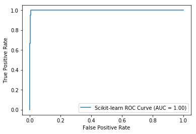

```python
roc_plot = plot_roc_curve(sk_model, x_val, y_val, name = 'Scikit-learn ROC Curve')
```

This graph looks different compared to the **ROC plot** you saw earlier. In fact, it almost seems perfect.

Let's look at the confusion matrix to get a better idea of how the model performed on this fold:

```
Text(0.5,15,'Predicted')
```

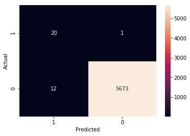

```python
conf_matrix = confusion_matrix(y_val, preds)
ax = sns.heatmap(conf_matrix, annot = True, fmt = 'g')
ax.invert_xaxis()
ax.invert_yaxis()
plt.ylabel('Actual')
plt.xlabel('Predicted')
```

The above cell show the **confusion matrix** for a specific validation fold. It has very good accuracy in labeling normal data points and does very well with anomaly points. Additrionally, you can see that there are barely any anomalies in this validation fold if you count the entries in the top row: 21 anomalies to 5,685 normal points. It is no wonder the, that having a higher weight on the anomaly helped the model factor in these anomalies in its learning process, resulting in better performance in anomaly detection.

The model did quite well on correctly classifying the anomalies, but the goal of validation in this case is just to help nudge the hyperparameters setting in the right direction. Based on the results of the validation process, you know that the optimal hyperparameter value lies within the values of 10 and 15 because those settings produced the best results.

Of course, you can narrow the range further to include values between 10 and 15 for the anomaly weights and represt this process again and again further reducing the range until a good, optimal value is found. After a certain precision, however, you will find that you are getting diminsihing returns, and that the effort you put into hyperparameter tuning only produces near-negligible boosts in performance.

With that, you know how to train, evaluate, and validate a logistic regression model in scikit-learn.

### PySpark

We have provided the versions of the modules we will be using . Installing PySpark can be a little complicated as it's not matter of doing *pip install PySpark* depending on the version, so beware of that.

### PySpark: Data Processing

Here are the import statements:

```python
import pyspark #
from pyspark.sql import SparkSession
from pyspark import SparkConf, SparkContext
from pyspark.sql.types import *
from pyspark.ml.feature import VectorAssembler
from pyspark.ml import Pipeline
from pyspark.ml.classification import LogisticRegression as LogisticRegressionPySpark
import pyspark.sql.functions as F
import os
import seaborn as sns
from sklearn.metrics import confusion_matrix
from sklearn.metrics import roc_auc_score

import matplotlib #
import matplotlib.pyplot as plt

os.environ['SPARK_LOCAL_IP'] = '127.0.0.1'
spark = SparkSession.builder.master('local[*]').getOrCreate()
spark.sparkContext._conf.getAll()

print('pyspark: {}'.format(pyspark.__version__))
print('matplotlib: {}'.format(matplotlib.__version__))
print('seaborn: {}'.format(sns.__version__))
print('sklearn: {}'.format(sklearn.__version__))
```

```
pyspark: 2.4.5
matplotlib: 2.2.2
seaborn: 0.10.0
sklearn: 0.23.2
```

The above cell shows how to import the necessary modules and printing their versions. Once again, modules imported solely for the purpose of displaying versions are marked with a # so you may remove them and the print statement if required.

You will notice that there is some additional code relating to *PySpark* that you have had to define. With *PySpark*, you must define a Spark context and create a Spark session, What this really means is that you are creating a point of connection to the Spark engine, enabling the engine to run all of the code relating to Spark functionality.

Let's now load the data set. *PySpark* has its own functionality for creating data frames, so you won't be using **pandas**. Execute the following:

```python
data_path = 'creditcard.csv'

df = spark.read.csv(data_path, header = True, inferSchema = True)
labelColumn = 'Class'
columns = df.columns
numericCols = columns
numericCols.remove(labelColumn)
print(numericCols)
```

```
['Time', 'V1', 'V2', 'V3', 'V4', 'V5', 'V6', 'V7', 'V8', 'V9', 'V10', 'V11', 'V12', 'V13', 'V14', 'V15', 'V16', 'V17', 'V18', 'V19', 'V20', 'V21', 'V22', 'V23', 'V24', 'V25', 'V26', 'V27', 'V28', 'Amount']
```

The above cell shows how to read the credit card data set in *PySpark* and removing the **Class** column from the list of columns. This is done because you don't want the **Class** columns to be included in the feature vector, as you will see.

Printing the columns is just to ensure that the label column has been removed successfully.

You can look at the data frame now just to ensure that it has been loaded properly. You will have to use the built-in functionality to convert to a **pandas** data frame, because Spark data frames are not very clean to look at. Look at the following two cells and their output:

```python
df.show(2)
```

```
+----+----------------+-------------------+----------------+-----------------+------------------+-------------------+-------------------+------------------+------------------+------------------+------------------+------------------+------------------+------------------+-----------------+------------…
|Time|              V1|                 V2|              V3|               V4|                V5|                 V6|                 V7|                V8|                V9|               V10|               V11|               V12|               V13|               V14|              V15|            …
+----+----------------+-------------------+----------------+-----------------+------------------+-------------------+-------------------+------------------+------------------+------------------+------------------+------------------+------------------+------------------+-----------------+------------…
|   0|-1.3598071336738|-0.0727811733098497|2.53634673796914| 1.37815522427443|-0.338320769942518|  0.462387777762292|  0.239598554061257|0.0986979012610507| 0.363786969611213|0.0907941719789316|-0.551599533260813|-0.617800855762348|-0.991389847235408|-0.311169353699879| 1.46817697209427|-0.470400525…
|   0|1.19185711131486|   0.26615071205963|0.16648011335321|0.448154078460911|0.0600176492822243|-0.0823608088155687|-0.0788029833323113|0.0851016549148104|-0.255425128109186|-0.166974414004614|  1.61272666105479|  1.06523531137287|  0.48909501589608|-0.143772296441519|0.635558093258208| 0.463917041…
+----+----------------+-------------------+----------------+-----------------+------------------+-------------------+-------------------+------------------+------------------+------------------+------------------+------------------+------------------+------------------+-----------------+------------…
only showing top 2 rows
```

The output of the Spark data frame is shown in the cell above. Since there are so many columns in the data frame, the output is very messy and very difficult to read. Fortunately, there is built-in functionality to convert **PySpark** dataframes into **pandas** data frames, making it much easier to view the rows in the Spark data frame. Now compare this to the following:

```python
df.toPandas().head()
```

|  | Time | V1 | V2 | V3 | V4 | V5 | V6 | V7 | V8 | V9 | ... | V21 | V22 | V23 | V24 | V25 | V26 | V27 | V28 | Amount | Class |
| --- | --- | --- | --- | --- | --- | --- | --- | --- | --- | --- | --- | --- | --- | --- | --- | --- | --- | --- | --- | --- | --- |
| 0 | 0 | -1.359807 | -0.072781 | 2.536347 | 1.378155 | -0.338321 | 0.462388 | 0.239599 | 0.098698 | 0.363787 | ... | -0.018307 | 0.277838 | -0.110474 | 0.066928 | 0.128539 | -0.189115 | 0.133558 | -0.021053 | 149.62 | 0 |
| 1 | 0 | 1.191857 | 0.266151 | 0.166480 | 0.448154 | 0.060018 | -0.082361 | -0.078803 | 0.085102 | -0.255425 | ... | -0.225775 | -0.638672 | 0.101288 | -0.339846 | 0.167170 | 0.125895 | -0.008983 | 0.014724 | 2.69 | 0 |
| 2 | 1 | -1.358354 | -1.340163 | 1.773209 | 0.379780 | -0.503198 | 1.800499 | 0.791461 | 0.247676 | -1.514654 | ... | 0.247998 | 0.771679 | 0.909412 | -0.689281 | -0.327642 | -0.139097 | -0.055353 | -0.059752 | 378.66 | 0 |
| 3 | 1 | -0.966272 | -0.185226 | 1.792993 | -0.863291 | -0.010309 | 1.247203 | 0.237609 | 0.377436 | -1.387024 | ... | -0.108300 | 0.005274 | -0.190321 | -1.175575 | 0.647376 | -0.221929 | 0.062723 | 0.061458 | 123.50 | 0 |
| 4 | 2 | -1.158233 | 0.877737 | 1.548718 | 0.403034 | -0.407193 | 0.095921 | 0.592941 | -0.270533 | 0.817739 | ... | -0.009431 | 0.798278 | -0.137458 | 0.141267 | -0.206010 | 0.502292 | 0.219422 | 0.215153 | 69.99 | 0 |

5 rows × 31 columns

We used the PySpark's built-in functionality to convert the spark data frame into a pandas data frame for easier viewing. As seen in the cells above, it is extremely hard to read the direct output of a Spark data frame.

So whenever you want to check a Spark data frame, make sure to convert it to pandas if it has a lot of columns.

The data processing procedure for PySpark is slightly different than in pandas. To train the model, you must pass in a vector called **features**. Take a look at the following code:

```python
stages = []
assemblerInputs = numericCols
assembler = VectorAssembler(inputCols = assemblerInputs, outputCol = 'features')
stages += [assembler]

dfFeatures = df.select(F.col(labelColumn).alias('label'),*numericCols)
```

This defines the inputs to the assembler so that it knows what columns to transform into the features vector.

From herem let's add to the cell above and create the normal and anomaly data spplits as with the scikit-learn example.

```python
normal = dfFeatures.filter('Class == 0').sample(withReplacement = False, fraction = 0.5, seed = 2020)
anomaly = dfFeatures.filter('Class == 1')
normal_train, normal_test = normal.randomSplit([0.8, 0.2], seed = 2020)
anomaly_train, anomaly_test = anomaly.randomSplit([0.8, 0.2], seed = 2020)
```

The above cells show how to construct the **VectorAssembler** that will be used later to create a **feature vector** from the input data. You also create a normal and anomaly data split similar to how it was done in scikit-learn, and split it in a similar pashio into training and testing subsets.

Just like in the scikit-learn example, you combine the respective normal and anomaly splits to form your training and testing sets. This time, however, you won't have a validation set, so you are looking at an 80-20 split between the training and testing data.

```python
train = normal_train.union(anomaly_train)
test = normal_test.union(anomaly_test)
```

You have created the training and testing sets in a similar manner to how you did in scikit-learn, but with PySpark's functionality.

Let's finish the rest of the pipeline and create the feature vector:

```python
pipeline = Pipeline(stages = stages)
pipelineModel = pipeline.fit(dfFeatures)
train = pipelineModel.transform(train)
test = pipelineModel.transform(test)
selectedCols = ['label', 'features'] + numericCols
train = train.select(selectedCols)
test = test.select(selectedCols)

print('Training Dataset Count: ', train.count())
print('Testing Dataset Count: ', test.count())
```

```
Training Dataset Count:  114125
Testing Dataset Count:  28611
```

The above cell shows how to use a pipeline to create a feature vector from the data frame. This feature is what the logistic regression model will train on.

### PySpark: Model Training

You can now define and train the model:

```python
lr = LogisticRegressionPySpark(featuresCol = 'features', labelCol = 'label', maxIter = 10)

lrModel = lr.fit(train)

trainingSummary = lrModel.summary
pyspark_auc_score = trainingSummary.areaUnderROC
```

In the above cell you defined the PySpark logistic regression model, trained itm and found the AUC score using the built-in functions of the model.

### PySpark: Model Evaluation

Once the model has finished training, run the evaluation code:

```python
predictions = lrModel.transform(test)

y_true = predictions.select(['label']).collect()
y_pred = predictions.select(['prediction']).collect()

evluations = lrModel.evaluate(test)
accuracy = evluations.accuracy
```

Add the following code as well to display the metrics:

```python
print(f'AUC Score: {roc_auc_score(y_pred, y_true): .3%}')
print(f'PySpark AUC Score: {pyspark_auc_score: .3%}')
print(f'Accuracy Score: {accuracy: .3%}')
```

```
AUC Score:  95.635%
PySpark AUC Score:  97.983%
Accuracy Score:  99.888%
```

You computed the output metric. The AUC score is calculated using scikit-learn's scoring algorithm, while the PySpark AUC score metric comes from the training summary of the PySpark model. Finally, the accuracy score is also outputted.

You can see that the AUC score and the accuracy areq uite high, so let's examine the graphs.

First, let's look at the ROC curve:

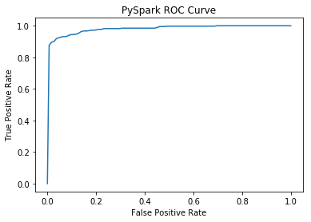

```python
pyspark_roc = trainingSummary.roc.toPandas()
plt.xlabel('False Positive Rate')
plt.ylabel('True Positive Rate')
plt.title('PySpark ROC Curve')
plt.plot(pyspark_roc['FPR'], pyspark_roc['TPR'])
```

The curve look quite optimal. Let's now look at the **confusion matrix** to get a detailed idea of how the model performs:

```
Text(0.5,15,'Predicted')
```

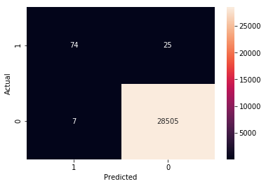

```python
conf_matrix = confusion_matrix(y_true, y_pred)
ax = sns.heatmap(conf_matrix, annot = True, fmt = 'g')
ax.invert_xaxis()
ax.invert_yaxis()
plt.ylabel('Actual')
plt.xlabel('Predicted')
```

The above cell shows the **confusion matrix** of the PySpark logistic regression model you just trained. The accuracy of correctly labeled points for the normal data is very high and is decent for the anomalous data.

PySpark does have an option to weight your data, but this is done on a sample-by-sample basis. What this means is that instead of passing in a weight disctionary for each class, you have to create a column in the dataframe with each anomaly being weighted a certain amount and each normal point being weighted as 1, for example. By default, everything is weighted as 1, so that means the PySpark model may have a greater potential in performance than the scikit-learn model.

### Summary

With the insight you gained from data analysis, you processed the data into training, testing, and validation sets in scikit-learn and PySpark (you only did a train-test split in PySpark, but you could have split the training data into training and validation sets just like in scikit-learn). From there, you constructed alogistic regression models in each framework and trained and evaluated on them. You looked at accuracy and AUC scores as metrics and looked at the ROC curve and confusion matrix to get a better idea of how the model performed. For the scikit-learn model, you performed k-fold cross-validation to help tune the hyperparameter. In the next notebook, you will keep your experiences with data nalysis and model creation in mind as you learn about MLOps and how you can operationalize your models.

Reference: Alla, S., & Adari, S. K. Beginning MLOps with MLFlow.